# DNA methylation and enrichment analysis

Kaisu Hiltunen

# Assignment week 11

1. Plot a heatmap of the methylation levels of the genes in top 5 differentially methylated regions (DMR) regions.
2. Run an enrichment analysis (rGREAT) of the genes within DMRs vs all genes of chromosome 22.
1. Describe what your enrichment analysis is testing exactly & describe the results.

```r
suppressPackageStartupMessages({
  library(GenomicRanges)
  library(epiwraps)
  library(ggplot2)
  library(rGREAT)
  library(AnnotationHub)
  library(ensembldb)
  library(bsseq)
  library(BiocParallel)
  library(edgeR)
  library(DMRcate)
  library(rtracklayer)
  library(sechm)
  library(pheatmap)
  library(viridis)
  library(data.table)
})
```

```r
ah <- AnnotationHub()
```

```
## snapshotDate(): 2022-10-31
```

```r
set.seed(40)
```

## Load the data

Download:

```r
options(timeout = 6000)
download.file("https://ethz-ins.org/content/w11_practical.zip", "w11_practical.zip")
unzip("w10.practical.zip")
```

# Enriched Heatmaps

## Differential Methylation Testing

### Bsseq object

The Bisulfite-sequenncing (BS-seq) data we are looking is from the [bsseqData](https://bioconductor.org/packages/release/data/experiment/html/bsseqData.html) package. It contains colon cancer samples with 3 patients with each a colon cancer and normal colon sample. Here we only look at chromosome 22.

```r
bs <- readRDS("./w11_practical/bs.rds")
pData(bs)
```

```
## DataFrame with 6 rows and 2 columns
##           Type        Pair
##    <character> <character>
## C1      cancer       pair1
## C2      cancer       pair2
## C3      cancer       pair3
## N1      normal       pair1
## N2      normal       pair2
## N3      normal       pair3
```

### Testing

Get annotations (hs):

```r
ensdb <- ah[["AH109336"]]

### genes ###
# create a GRanges object of the chromosome 22
chr22 <-  GRanges(seqnames=Rle(c("22")),
                  ranges = IRanges(1, end=195471971))

#retrieve the gene annotations for chromosome 22 using the genes() function
#specify the output to include columns gene_seq_start, gene_seq_end, gene_names
#filter to include only the genes within the range of chromosome 22
genesChr22 <- genes(ensdb, columns=c("gene_seq_start", "gene_seq_end", "gene_name"),
                    filter=GRangesFilter(chr22))

#set the sequence level style to match UCSC genome browser conventions
seqlevelsStyle(genesChr22) <- "UCSC"
```

## 1. Heatmap of the methylation levels of the genes in top 5 DMRs

Initial visualisation of all the genes in DMRs:

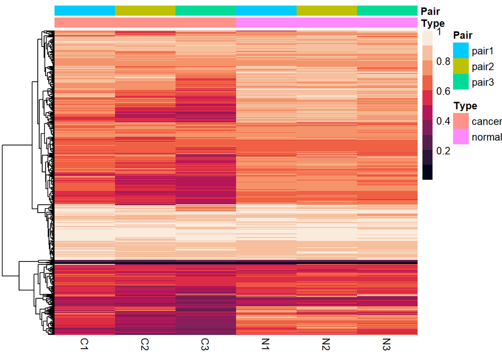

```r
# retrieve methylation levels of genes on chr22
# for testing we only use the 100 first genes (genesChr22[1:100])
# what="perRegion" indicates that methylation levels should be calculated for each region
metG <- bsseq::getMeth(bs,
                        regions=genesChr22,
                        what="perRegion")

# set the column names and rownames
colnames(metG) <- colnames(bs)
rownames(metG) <- genesChr22$gene_name

# Remove genes that have missing values (NA) for methylation levels
metG <- metG[!is.na(rowSums(metG)),]
#remove rows that dont have a name
metG <- metG[rownames(metG) != "",]
# Create a data frame named annotationCol that contains the sample annotations for the 'bs' object
annotationCol <- as.data.frame(pData(bs)[,c("Type","Pair")])

# add colnames
rownames(annotationCol) <- colnames(metG)

# creates a heatmap using the pheatmap function
# It takes the metPr matrix as input
pheatmap::pheatmap(metG,
                   cluster_rows=TRUE,
                   cluster_cols=FALSE,
                   annotation_col=annotationCol,
                   show_rownames = FALSE,
                   color=rocket(10))
```

### Differential methylation testing

DMRcate extracts and annotates differentially methylated regions (DMRs) using a kernel-smoothed estimate. It identifies genomic regions that exchibit significant differential methylation between groups or conditions. We use the min_smoothed_fdr statistic, aka the minimum smoothed false discovery rate, to sort the differentially methylated genes.

```r
# General design matrix
design <- model.matrix(~Type+Pair, data=pData(bs))

# Adapt design matrix for methylation data
methdesign <- modelMatrixMeth(design)


# Perform the annotation of the bisulfite sequencing data (bs) using the design matrix (methdesign)
# The code below calculates various statistics and annotation information for each CpG site in the data
seqAnnot <- sequencing.annotate(bs, methdesign, all.cov=TRUE, coef="Typenormal")

# The following line performs the differential methylation analysis. It takes annotated sequencing data (seqAnnot)
# The function specifies the number of comparison groups (C=2), min number of CpGs to define a region (min.cpgs=10), and the p-value cutoff for defining significant DMRs (pcutoff=0.01)
dmrcateRes <- dmrcate(seqAnnot, C=2, min.cpgs = 10, pcutoff=0.01)

# Extract the DMRs from the dmrcateRes
dmrRanges <- extractRanges(dmrcateRes, genome="hg38")

# Save DMR ranges in file
saveRDS(dmrRanges, "./w11_practical/dmr.rds")
# Filter the DMR ranges to only include those that overlap with genes
dmrRanges <- dmrRanges[!is.na(dmrRanges$overlapping.genes)]
# Sort the dmrRanges by the significance level
dmrRanges <- dmrRanges[order(dmrRanges$min_smoothed_fdr)]
```

Plot of the Chromosome 22 displaying the top DMR and CpG sites. The green color marks the CpG sites.

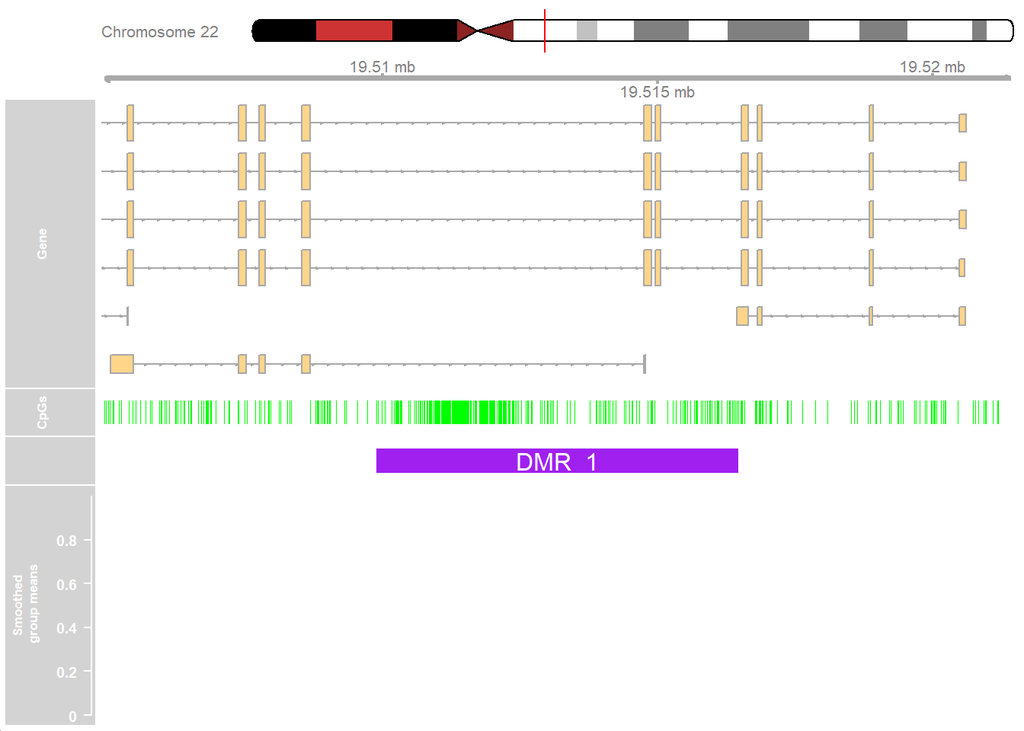

```r
# Plot the first DMR (dmr=1)


DMR.plot(dmrRanges, dmr=1, phen.col=c(rep("red", 3), rep("green",3)), CpGs=bs, genome="hg38")
```

Obtain the coordinates of the genes within DMRs.

```r
# Get the genes within Differentially methylated regions

# Retrieve the indices of the top DMRs based on the minimum smoothed FDR value
topIdx <- order(dmrRanges$min_smoothed_fdr)
# Remove any NA values from the gene vector
dmrRanges <- dmrRanges[!is.na(dmrRanges$overlapping.genes)]
# Extract the overlapping gene names from the top DMRs and
# Split the gene names into individual genes and combine them into a vector
#Reduce the list of genes into the top 5 DMR
genesDmr <- unlist(tstrsplit(dmrRanges[topIdx[1:5]]$overlapping.genes, split=", "))

# Retrieve the gene information for the DMR genes from the genesChr22 object
dmrGenes <- genesChr22[genesChr22$gene_name %in% genesDmr,]
```

Now that we have the list of genes from the top 5 DMRs we retrieve the methylation levels and plot the heatmap.

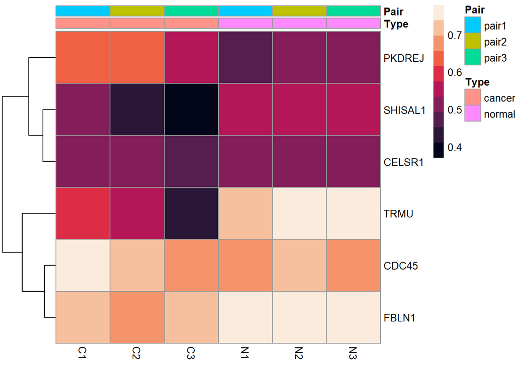

```r
#Retrieve the methylation levels of the DMR regions from the metG matrix
metG <- bsseq::getMeth(bs,
                        regions=genesChr22,
                        what="perRegion")

# set the column names and rownames
colnames(metG) <- colnames(bs)
rownames(metG) <- genesChr22$gene_name

# Remove genes that have missing values (NA) for methylation levels
metG <- metG[!is.na(rowSums(metG)),]


# Create a data frame named annotationCol that contains the sample annotations for the 'bs' object
annotationCol <- as.data.frame(pData(bs)[,c("Type","Pair")])

# add colnames
rownames(annotationCol) <- colnames(metG)

# extract the top genes from the metG matrix
dmrMet <- metG[rownames(metG) %in% dmrGenes$gene_name,]

# creates a heatmap using the pheatmap function
# It takes the dmrMet matrix as input
# creates a heatmap using the pheatmap function
# It takes the metPr matrix as input
pheatmap::pheatmap(dmrMet,
                   cluster_rows=TRUE,
                   cluster_cols=FALSE,
                   annotation_col=annotationCol,
                   show_rownames = TRUE,
                   color=rocket(10))
```

## Discussion

In the above plot, we see the heatmap of the methylation levels of the genes found in the top 5 DMR regions. However, the results look a bit underwhelming. For example, CDC45 and FBLN1 don’t differ that much in colors in between the conditions.

## 2. Enrichment analysis of the genes within DMRs

We use rGREAT for the enrichment analysis of the DMR genelist. As a background we use all the genes in chromosome 22.

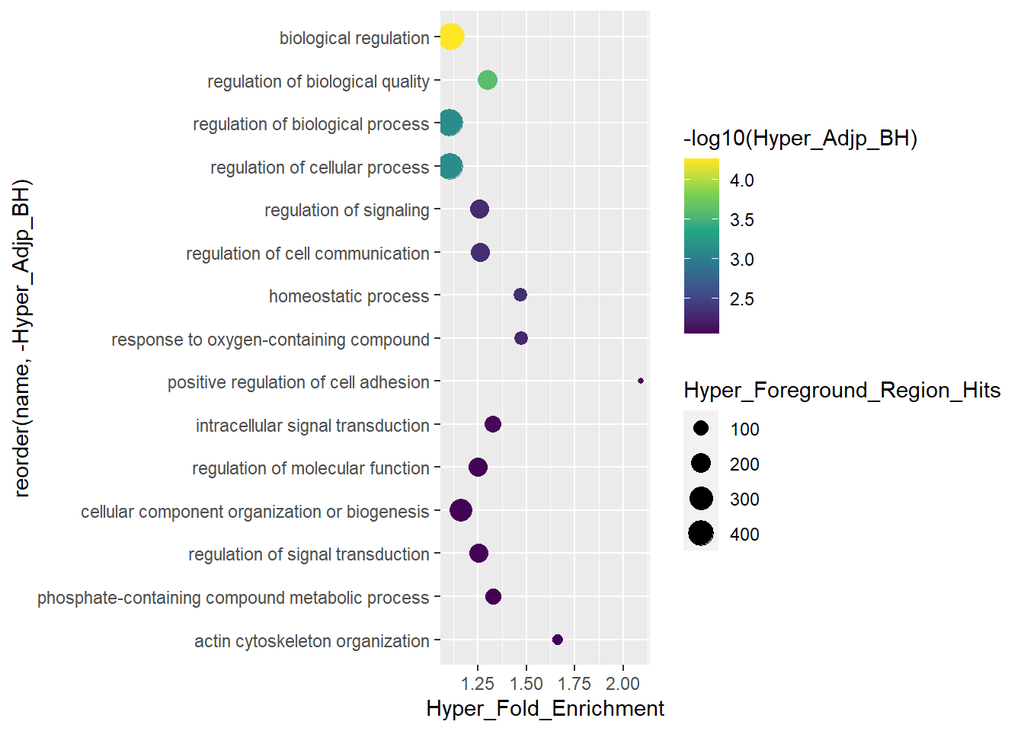

```r
#Get the complete gene list for enrichment analysis
genesDmr <- unlist(tstrsplit(dmrRanges[topIdx]$overlapping.genes, split=", "))
# Retrieve the gene information for the DMR genes from the genesChr22 object
allDMRGenes <- genesChr22[genesChr22$gene_name %in% genesDmr,]
#sends DMRs and the background of regions (entire chr 22) to a remote server
res<-rGREAT::submitGreatJob(allDMRGenes, bg=genesChr22, species="hg38")
table_cluster<-rGREAT::getEnrichmentTables(res)

#get the GO table
bp<-table_cluster$`GO Biological Process`

#plot the GO terms
ggplot(head(bp,15), aes(Hyper_Fold_Enrichment, reorder(name, -Hyper_Adjp_BH), size=Hyper_Foreground_Region_Hits, color=-log10(Hyper_Adjp_BH))) + geom_point() + scale_color_viridis_c()
```

### Discussion

In the above plot, we see the results from the enrichment analysis with the differentially methylated regions. The analysis compares the genomic regions of interest against the background genome and identifies functional annotations that are over-represented in the input regions. Methylation of gene bodies increases trans cription of the gene. Thus, the GO processes that are enriched with methylated genes are expected to be more expressed in the cells.

The most enriched biological process GO term is “biological regulation”. The other most enriched terms belong to the same umbrella of processes, e.g. “regulation of biological quality”, and “regulation of cellular process”. This would make sense as in cancer the normal cell regulatory processes are disrupted, leading to overgrowth and disruption of normal cell cycle. Cell communication and signaling are also known to be disrupted in cancer cells.